# Insurance Cost Regression

Zhiwei Lin

2023-01-24

- **Introduction**
- **Data Preprocessing**
- **Data Visualization**
- **Correlation Analysis**
- **Model Selection and Training**
  - Random Forest
  - Extreme Gradient Boosting(xgboost)
- **Model Evaluation**
  - Random Forest
  - Extreme Gradient Boosting(xgboost)
- **Concolusion**

# Introduction

The goal of this R markdown is to predict insurance costs using medical cost personal datasets provided by https://github.com/stedy/Machine-Learning-with-R-datasets/blob/master/insurance.csv.

```r
library(tidyverse)
library(AnalysisLin)
```

# Data Preprocessing

```r
data<-read.csv("/Users/zhiweilin/Downloads/insurance.csv", header =T, na.string=c("","NA"))
```

```r
desc_stat(data) # desc_stat() is a function from my personal EDA package AnalysisLin. The function is used to generate some key statistics for the dataset.
```

```
## Descriptive Statistics Results:
## =========================================================================
##               age     sex       bmi      children smoker    region
## count         1338    1338      1338     1338     1338      1338
## unique        47      2         548      6        2         4
## duplicate     1       1         1        1        1         1
## null          0       0         0        0        0         0
## null_rate     0       0         0        0        0         0
## type          integer character numeric  integer  character character
## min           18      <NA>      15.96    0        <NA>      <NA>
## p25           27      <NA>      26.29625 0        <NA>      <NA>
## mean          39.207  <NA>      30.6634  1.0949   <NA>      <NA>
## median        39      <NA>      30.4     1        <NA>      <NA>
## p75           51      <NA>      34.69375 2        <NA>      <NA>
## max           64      <NA>      53.13    5        <NA>      <NA>
## sd            14.05   <NA>      6.0982   1.2055   <NA>      <NA>
## kurtosis      1.7551  <NA>      2.945    3.1972   <NA>      <NA>
## skewness      0.0556  <NA>      0.2837   0.9373   <NA>      <NA>
## jarque_pvalue 0       <NA>      0        0        <NA>      <NA>
##               charges
## count         1338
## unique        1337
## duplicate     1
## null          0
## null_rate     0
## type          numeric
## min           1121.8739
## p25           4740.28715
## mean          13270.4223
## median        9382.033
## p75           16639.912515
## max           63770.42801
## sd            12110.0112
## kurtosis      4.5958
## skewness      1.5142
## jarque_pvalue 0
```

Some data Insights:

- Participants’ ages range from 18 to 64, with a mean of 39.2 and a median of 39.
- Charges range from 1121.874 to 63770.43, with a mean of 13270.42 and a median of 9382.03.
- A duplicate row exists and should be removed from the dataset.
- The dataset is free of missing values.
- Certain non-numerical/categorical variables need encoding: sex, smoker, and region.
- All numerical variables display Jarque-Bera p-values below 0.05, which implies their kurtosis and skewness are not followed normal distribution. This implies that none of them adhere to a normal distribution.

```r
data<-distinct(data) # Remove duplicate rows based on all columns
```

```r
data <- mutate_at(data, vars(sex,smoker,region), as.factor)
```

The variables ‘sex’, ‘smoker’, and ‘region’ are converted from character variables to factor variables.

# Data Visualization

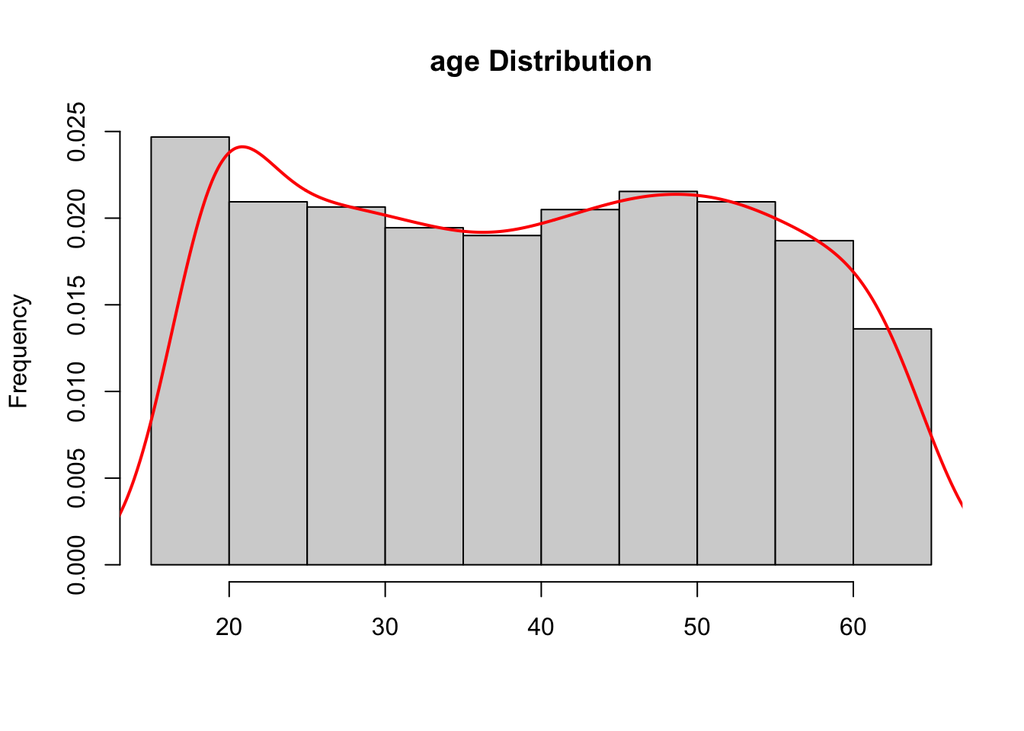

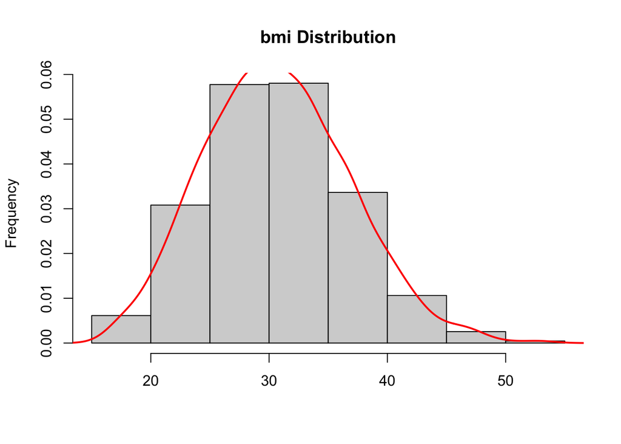

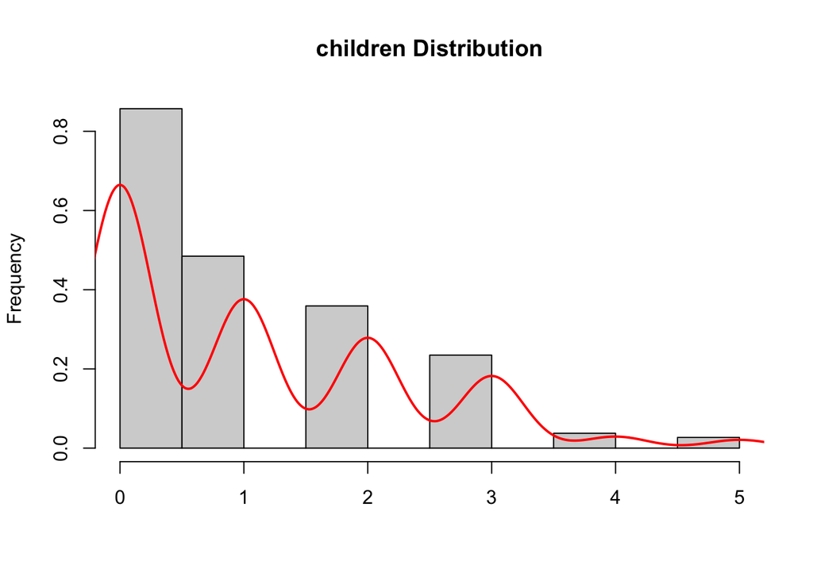

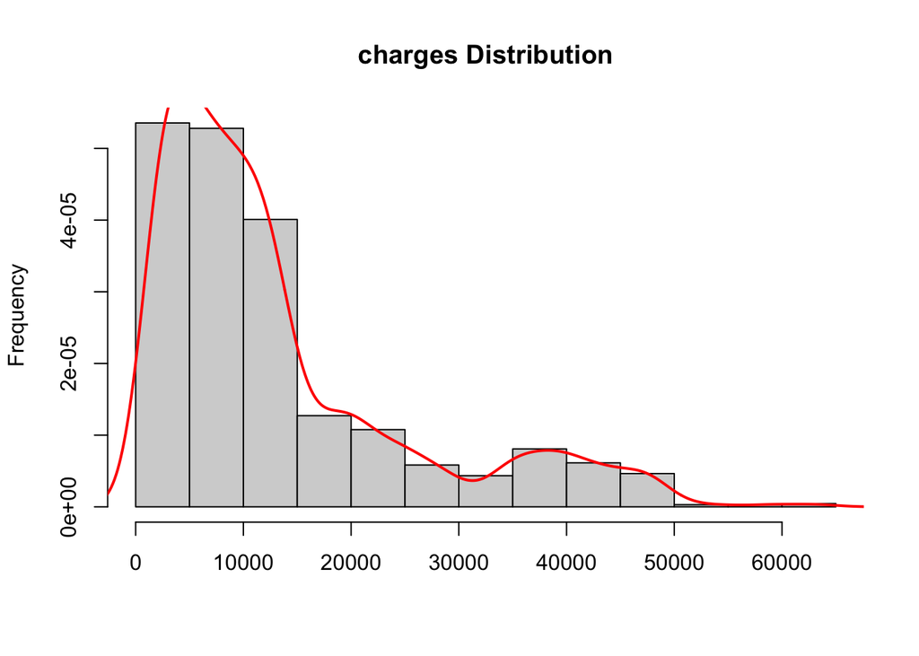

```
## list()
```

```r
numeric_plot(data,prob=T,dens=T) # numeric_plot() is a function from my personal EDA package AnalysisLin. The function is used to generate histogram/line plot for all numerical variables.
```

Some takeaways:

- From age distribution plot, age is roughly uniform distributed in the range between 18 to 64.
- From BMI distribution plot, BMI distribution is a bell shape with a center around 30.
- From Children Distribution plot, most participants have children 0-1.
- From Charge Distribution plot, most participants pay insurance premium around 10000.

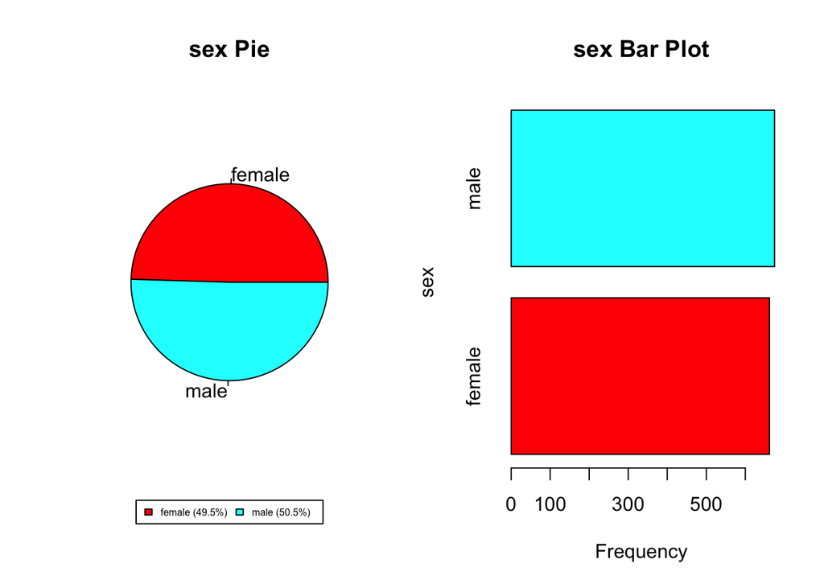

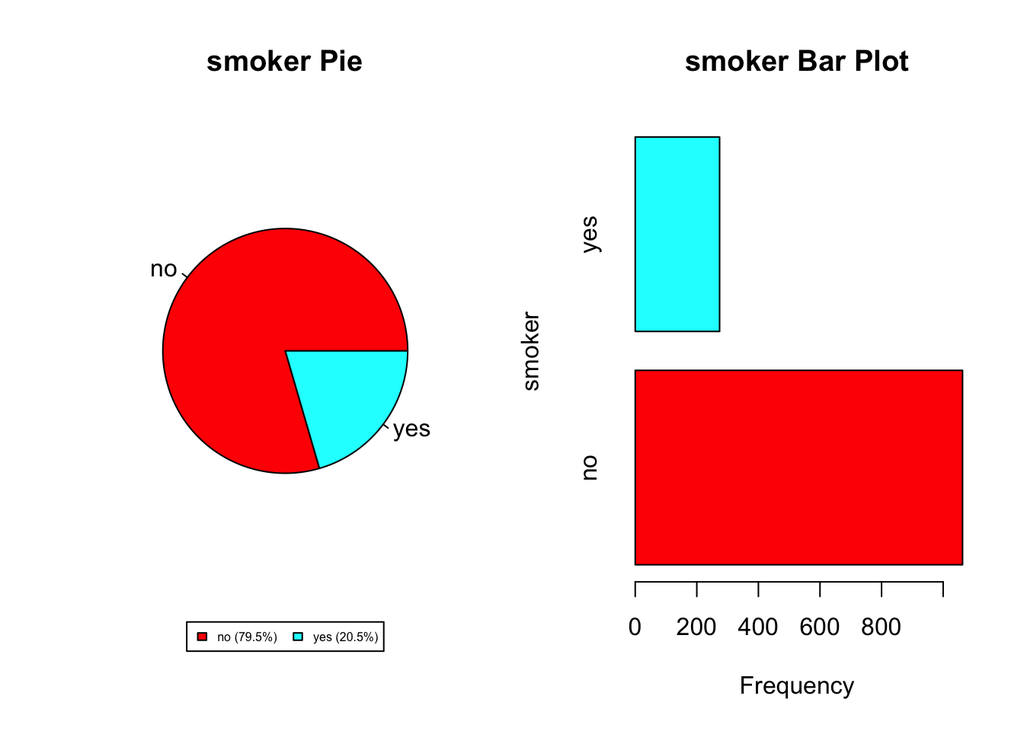

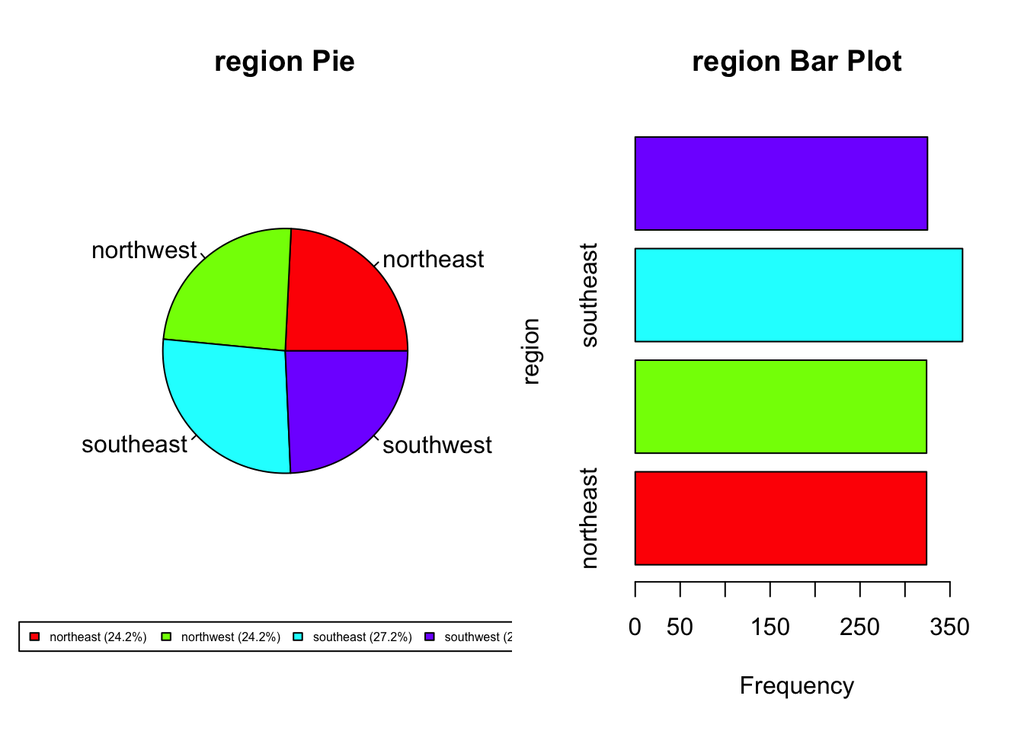

```r
categoric_plot(data,n_col = 2,bar_legend = F) # categorical_plot() is a function from my personal EDA package AnalysisLin. The function is used to generate pie/bar plot for all categrical(level) variables.
```

# Correlation Analysis

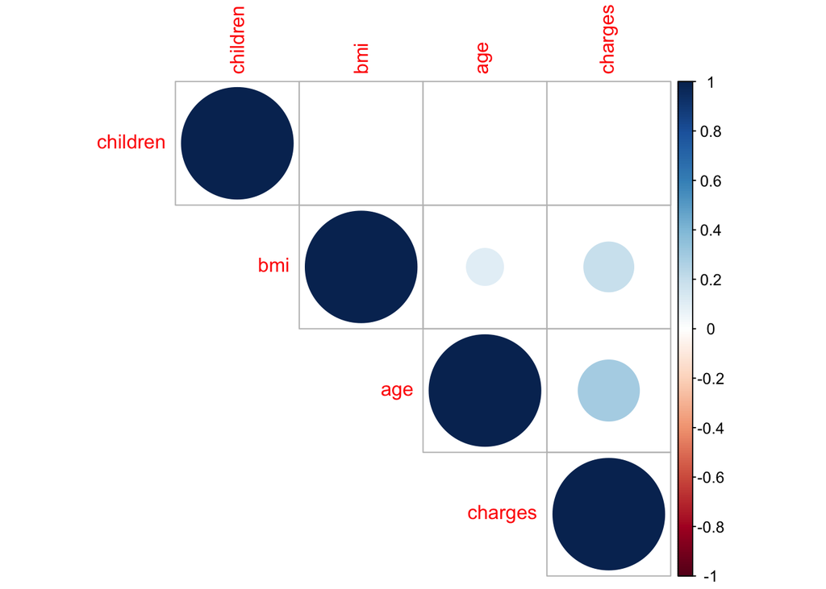

```
##        row   column        cor            p
## 4      age  charges 0.29830821 0.000000e+00
## 5      bmi  charges 0.19840083 2.469136e-13
## 1      age      bmi 0.10934361 6.164372e-05
## 6 children  charges 0.06738935 1.371703e-02
## 2      age children 0.04153621 1.290128e-01
## 3      bmi children 0.01275466 6.412463e-01
```

```r
numeric_columns <- sapply(data, is.numeric)
numeric_data <- data[, numeric_columns]
corr_matrix(numeric_data,corrplot=T) #corr_matrix() is a function from my personal EDA package, AnalysisLin. The function is used to generated a table of correlation between variables and a plot of correlations.
```

For numerical variables only, age is most importnat variable in determining insurance permium, followed by bmi.

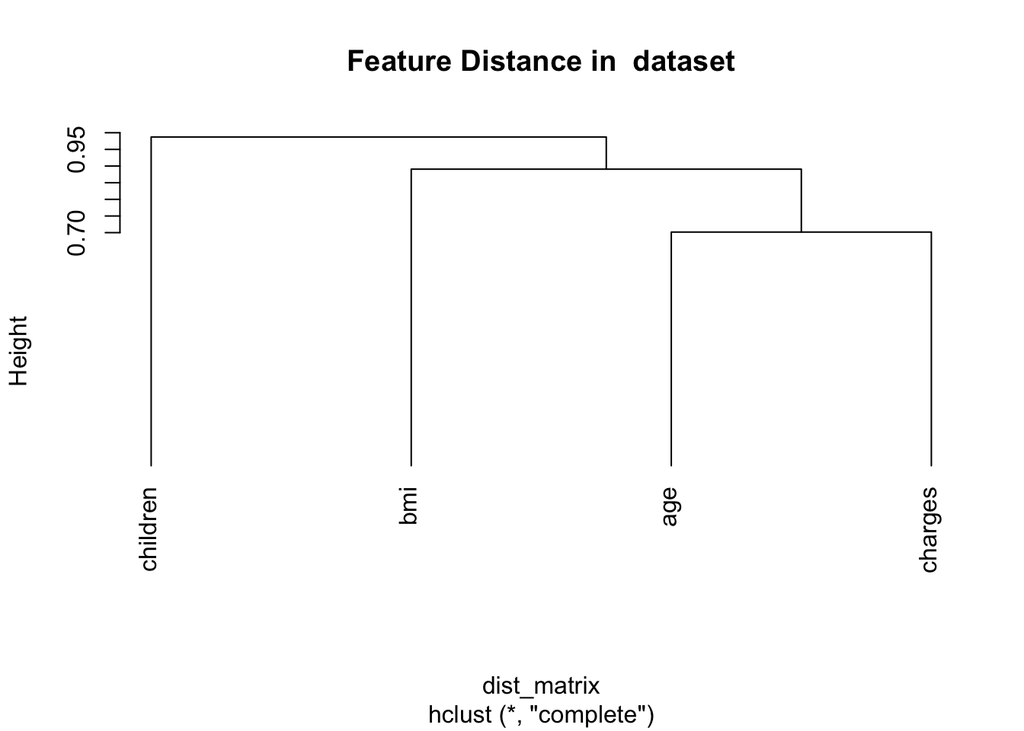

```r
corr_cluster(numeric_data)
```

This is correlation clustering that tells the relationships between four numerical variables. As can be seen, variables age is closest to variable charges.

# Model Selection and Training

## Random Forest Model

```r
library(caret)
library(randomForest)
set.seed(123)
training.samples <- data$charges %>%
  createDataPartition(p = 0.8, list = FALSE)
train.data  <- data[training.samples, ]
test.data <- data[-training.samples, ]
```

split dataset into train and test data, with 80% train data and 20% test data.

```r
set.seed(123)
rf_model <- train(
  charges ~., data = train.data, method = "rf",
  trControl = trainControl("cv", number = 10),
  importance = TRUE
  )
```

10-fold cross-validation is used

```r
rf_model$bestTune #best set of tuning parameter.
```

```
##   mtry
## 2    5
```

## Extreme Gradient Boosting Model

```r
library(xgboost)
xgb_model <- train(
  charges ~ ., data = train.data, method = "xgbTree",
  trControl = trainControl(method = "cv", number = 10),
  verbosity = 0
)
```

```r
xgb_model$bestTune #best set of tuning parameter.
```

```
##    nrounds max_depth eta gamma colsample_bytree min_child_weight subsample
## 34      50         2 0.3     0              0.8                1         1
```

# Model Evaluation

## Random Forest Result

```r
varImp(rf_model)
```

```
## rf variable importance
##
##                  Overall
## smokeryes       100.0000
## bmi              51.1292
## age              50.7188
## children          4.9639
## regionsoutheast   2.0844
## regionsouthwest   0.3861
## regionnorthwest   0.3150
## sexmale           0.0000
```

In random forest model, smokeryes is the most significant variable in determining insurance charges, followed by BMI and age. Other factors have minor to no impact on the charges

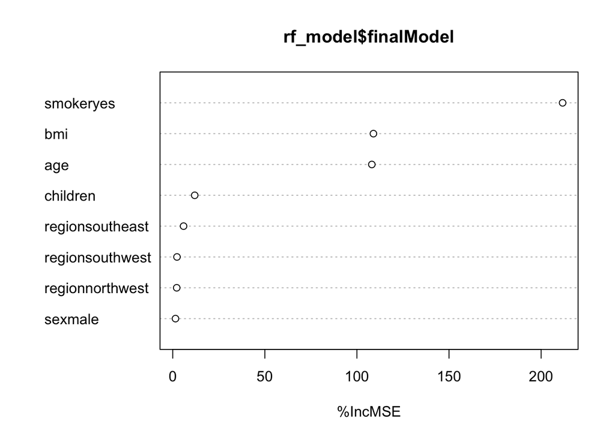

```r
varImpPlot(rf_model$finalModel, type = 1)
```

```r
rf_predictions <- rf_model %>% predict(test.data)
head(rf_predictions)
```

```
##         5         9        14        19        25        28
##  4877.633  7903.622 12120.191 13150.115  6576.011 12628.450
```

```r
RMSE(rf_predictions, test.data$charges)
```

```
## [1] 4806.051
```

## Extreme Gradient Boosting Result

```r
varImp(xgb_model)
```

```
## xgbTree variable importance
##
##                   Overall
## smokeryes       100.00000
## bmi              22.97129
## age              14.01767
## children          1.11484
## regionsouthwest   0.14746
## regionsoutheast   0.10335
## sexmale           0.02424
## regionnorthwest   0.00000
```

In XGBoost model, smokeryes is the most significant variable in determining insurance charges, followed by BMI and age. Other factors have minor to no impact on the charges

```r
xgb_predictions <- xgb_model %>% predict(test.data)
head(xgb_predictions)
```

```
## [1]  5323.405  7166.240 12638.623 10981.429  7134.224 12472.825
```

```r
RMSE(xgb_predictions, test.data$charges)
```

```
## [1] 4787.083
```

# Conclusion

Both the Random Forest and XGBoost models yield the same result, such that “smoker,” “bmi,” and “age” are three crucial variables that determines insurance premiums. However, the XGBoost model outperforms the Random Forest model with a lower Root Mean Squared Error (RMSE). In general, if your dataset is small and you value simplicity, the Random Forest model is a solid choice. Conversely, for larger datasets where predictive accuracy is your goal, the XGBoost model is a better fit.